# Baseball Data Analysis

Author: Bo Liu Date: 23 Jul 2017

## Summary

This is about exploring baseball data in Python.

The dataset is Baseball Data - A data set containing complete batting and pitching statistics from 1871 to 2014, plus fielding statistics, standings, team stats, managerial records, post-season data, and more.

## Questions

We care about the following two questions:

1. What make players more likely to be voted into Hall of Fame.
2. What are the characteristics of baseball players with the highest salaries?

To solve those questions first make it more specific as follow:

1. What’s the relationship of batting, pitching and fielding statistics and Hall of Fame members?
2. What’s the relationship of Hall of Fame members, All-star player, awards, and salary?

## Loading Data

Downloading data from [this link](http://seanlahman.com/files/database/baseballdatabank-2017.1.zip).

This dataset contains 28 csv including pitching, hitting, and fielding statistics for Major League Baseball from 1871 through 2016. It includes data from the two current leagues (American and National), the four other “major” leagues (American Association, Union Association, Players League, and Federal League), and the National Association of 1871-1875.

More details are in the [readme file](http://seanlahman.com/files/database/readme2016.txt).

To answer those two questions, we only need some of those files including Master, AllStarFull, HallofFame, AwardsPlayers, Salaries, Batting, Pitching, Fielding.

```python
import pandas as pd
import numpy as np
import matplotlib.pyplot as plt
from __future__ import division
```

```python
# read csv files
def read_csv(filename):
    path =  './baseballdatabank-2017.1/core/'
    return pd.read_csv(path+filename)

# load files that relevent to our questions
Players = read_csv('Master.csv')
Allstar = read_csv('AllstarFull.csv')
Awards = read_csv('AwardsPlayers.csv')
Batting = read_csv('Batting.csv')
Fielding = read_csv('Fielding.csv')
HallOfFame = read_csv('HallOfFame.csv')
Pitching = read_csv('Pitching.csv')
Salaries = read_csv('Salaries.csv')
```

## Investigating the Data

First have a look at the size of dataset.

```python
Players.shape
```

```
(19105, 24)
```

```python
HallOfFame_players = HallOfFame.playerID.unique()
```

To anylysis the relationship between batting, pitching, fielding statistcs and Players voted into Hall of Fame, we have to choose typical feature in each of those sporting data.We choose H in Batting and Pitching which reprsents hits in a game. And choose A in fielding data which represents Assists in a game.

Since put all those corresponding variables in one dataframe is convenient for our analysis, let's do subsetting and mergging.

```python
new_batting = {'playerID':Batting['playerID'],'H_batting' : Batting['H']}
new_pitching = {'playerID': Pitching['playerID'],'H_pitching': Pitching['H']}
new_fielding = {'playerID': Fielding['playerID'],'Assists': Fielding['A']}
new_batting = pd.DataFrame(new_batting)
new_pitching = pd.DataFrame(new_pitching)
new_fielding = pd.DataFrame(new_fielding)

new_df = new_batting.merge(new_pitching, on='playerID', how='inner')
new_df = new_df.merge(new_fielding,on='playerID', how='inner')
```

Now we have a new dataframe that contains all the elements we need.

```python
new_df.head()
```

|  | H_batting | playerID | H_pitching | Assists |
| --- | --- | --- | --- | --- |
| 0 | 44 | allisdo01 | 11 | 15.0 |
| 1 | 44 | allisdo01 | 11 | 23.0 |
| 2 | 44 | allisdo01 | 11 | 2.0 |
| 3 | 44 | allisdo01 | 11 | 8.0 |
| 4 | 44 | allisdo01 | 11 | 17.0 |

Check out statistical data betwen Hall of Fame players and Non-Hall of Fame players.

```python
new_df['is_HOF'] = new_df['playerID'].isin(HallOfFame_players)

new_df.groupby('is_HOF').describe()['Assists']
new_df.groupby('is_HOF').describe()['H_batting']
new_df.groupby('is_HOF').describe()['H_pitching']
```

| is_HOF | count | mean | std | min | 25% | 50% | 75% | max |
| --- | --- | --- | --- | --- | --- | --- | --- | --- |
| False | 3816068.0 | 96.309563 | 87.901406 | 0.0 | 27.0 | 67.0 | 153.0 | 772.0 |
| True | 2218411.0 | 141.576206 | 99.768692 | 0.0 | 54.0 | 137.0 | 219.0 | 753.0 |

Finally, create plots to show our findings, this part refered to [this](http://blog.bharatbhole.com/creating-boxplots-with-matplotlib/) article.

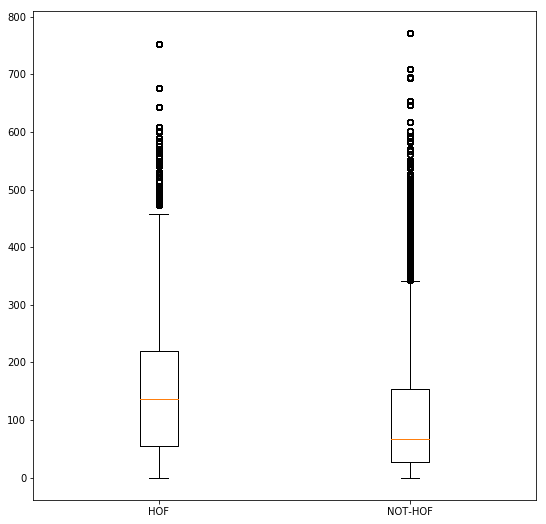

```python
collectn_1 = new_df.loc[new_df.is_HOF==True, 'H_pitching']
collectn_2 = new_df.loc[new_df.is_HOF==False, 'H_pitching']

data_to_plot = [collectn_1,collectn_2]
# Create a figure instance
fig = plt.figure(1,figsize=(9, 9))

# Create an axes instance
ax = fig.add_subplot(111)

# Create the boxplot
bp=ax.boxplot(data_to_plot)
ax.set_xticklabels(['HOF', 'NOT-HOF'])
plt.show()
```

### What’s the relationship of Hall of Fame members, All-star player, awards, and salary?

Creat new dataframe that contains information of what we need.

```python
new_salaries = {'playerID':Salaries['playerID'],'salary' : Salaries['salary']}
new_salaries = pd.DataFrame(new_salaries)
new_salaries.head()
```

|  | playerID | salary |
| --- | --- | --- |
| 0 | barkele01 | 870000 |
| 1 | bedrost01 | 550000 |
| 2 | benedbr01 | 545000 |
| 3 | campri01 | 633333 |
| 4 | ceronri01 | 625000 |

This time we care about three variables incuding which playID refer to Hall of Fame, Allstar and Awards. So create new columns 'is_HOF', 'is_Allstar','is_Award' to indicate player's history.

```python
new_salaries['is_HOF'] = new_salaries['playerID'].isin(HallOfFame_players)
new_salaries['is_Allstar'] = new_salaries['playerID'].isin(Allstar_players)
new_salaries['is_Award'] = new_salaries['playerID'].isin(Awards_players)
new_salaries.head()
```

|  | playerID | salary | is_HOF | is_Allstar | is_Award |
| --- | --- | --- | --- | --- | --- |
| 0 | barkele01 | 870000 | False | True | False |
| 1 | bedrost01 | 550000 | True | True | True |
| 2 | benedbr01 | 545000 | False | True | False |
| 3 | campri01 | 633333 | False | False | False |
| 4 | ceronri01 | 625000 | False | False | True |

```python
sort_salaries = new_salaries.salary.sort_values(ascending=False)

len(sort_salaries)*0.1
```

```
2642.8
```

We get 2642 which is the number of top 10 profitable palyers.

Subbset data to find out if there are some paterns.

```python
high_salary_player=new_salaries.loc[new_salaries.salary>sort_salaries[2642]]
```

```python
high_salary_player.head()
```

|  | playerID | salary | is_HOF | is_Allstar | is_Award |
| --- | --- | --- | --- | --- | --- |
| 0 | barkele01 | 870000 | False | True | False |
| 3 | campri01 | 633333 | False | False | False |
| 4 | ceronri01 | 625000 | False | False | True |
| 5 | chambch01 | 800000 | True | True | True |
| 8 | garbege01 | 772000 | False | False | False |

```python
sum(high_salary_player.is_HOF)/len(high_salary_player)
```

```
0.2596220062743898
```

```python
sum(high_salary_player.is_Allstar)/len(high_salary_player)
```

```
0.53095110566990589
```

```python
sum(high_salary_player.is_Award)/len(high_salary_player)
```

```
0.38442114928456655
```

This also concludes our report.